# Machine Learning: Logistic Regression with R

Mutua Kilai

2023-01-02

# Introduction

In this project, we fit a logistic regression model to predict customers who can click social network adverts. The packages used in this section are given:

```r
# helper packages

library(dplyr) # data manipulation

library(ggplot2) # data visualization

library(rsample) # splitting

library(janitor) # creating tables

library(visdat) # visualize missing values

# modeling packages

library(caret)

# feature interpretability

library(vip)
```

The data set is imported via `read.csv()` function.

```r
# importing data

Data <- read.csv("Social_Network_Ads.csv")
```

We drop the first column since it is not useful in the modeling part.

```r
Data <- Data[,-1]
```

We investigate if there were missing values in the data set using `visdat`.

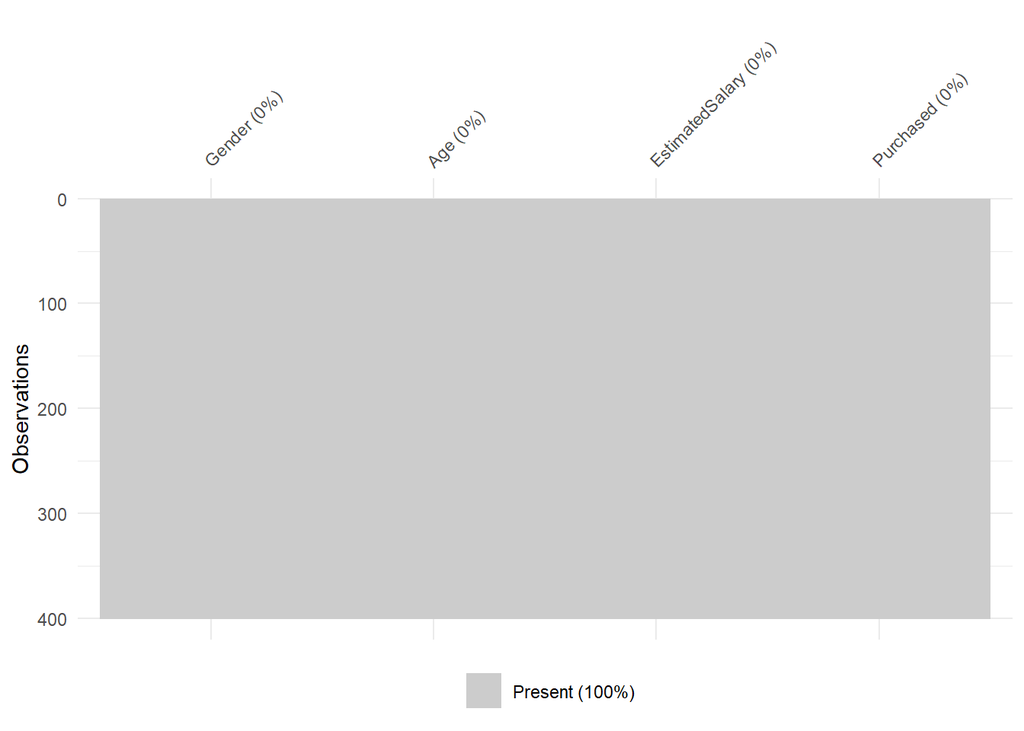

```r
vis_miss(Data)
```

A brief EDA is conducted on the data to visualize the distribution of various attributes.

```r
# section of data

Datahe <- head(Data)

knitr::kable(Datahe)
```

| Gender | Age | EstimatedSalary | Purchased |
| --- | --- | --- | --- |
| Male | 19 | 19000 | 0 |
| Male | 35 | 20000 | 0 |
| Female | 26 | 43000 | 0 |
| Female | 27 | 57000 | 0 |
| Male | 19 | 76000 | 0 |
| Male | 27 | 58000 | 0 |

The `ggplot2` package is used to do the visualization.

Majority of the respondents are females.

```r
Gender <- Data %>%
  tabyl(Gender) %>%
  adorn_pct_formatting(digits = 1)
knitr::kable(Gender)
```

| Gender | n | percent |
| --- | --- | --- |
| Female | 204 | 51.0% |
| Male | 196 | 49.0% |

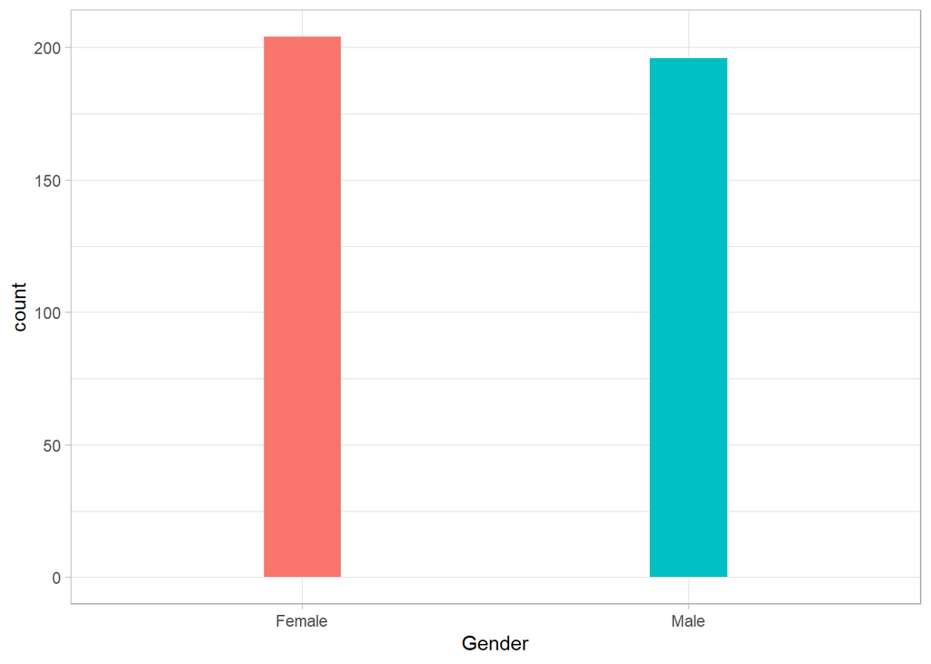

```r
# gender

ggplot(Data, aes(x = Gender, fill = Gender)) + geom_bar(width = 0.2,show.legend = FALSE) + theme_light()
```

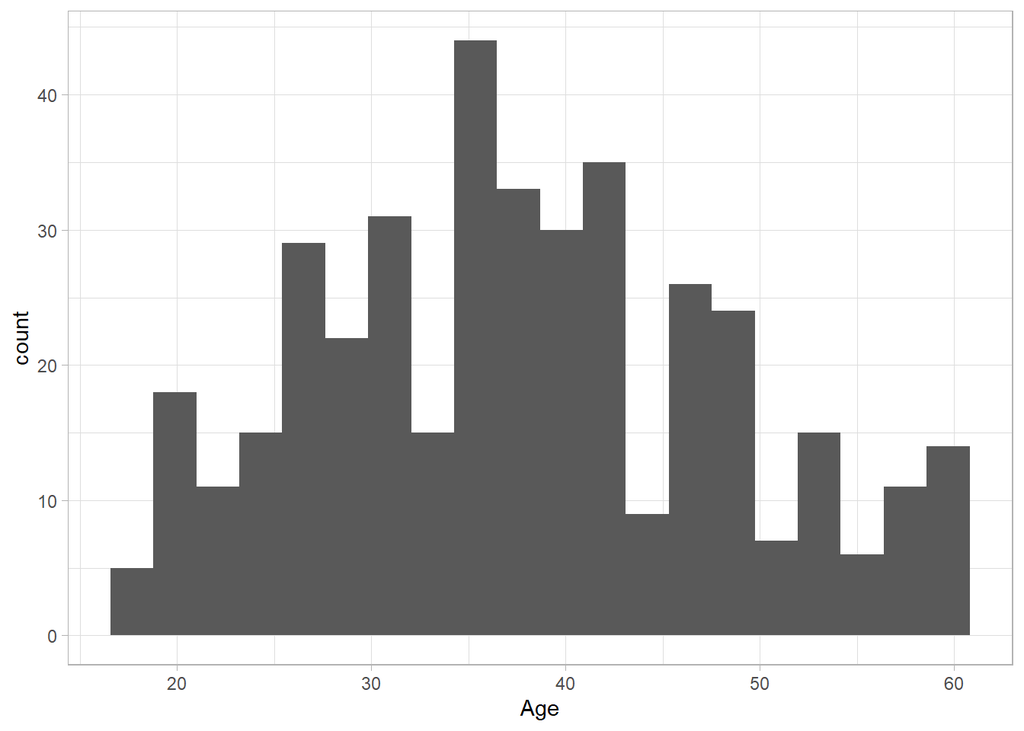

```r
# age

ggplot(Data, aes(x = Age)) + geom_histogram(bins = 20) + theme_light()
```

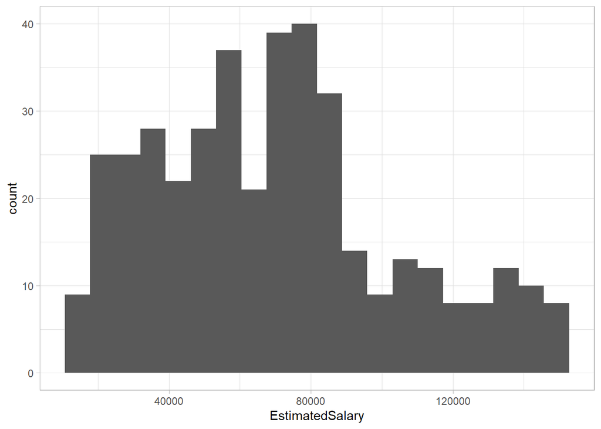

```r
# estimated salary

ggplot(Data, aes(EstimatedSalary)) + geom_histogram(bins = 20) + theme_light()
```

The `target` variable is whether a customer purchased or did not purchase. Majority of the customers do not purchase.

```r
Data <- Data %>%
  mutate(Purchased = ifelse(Purchased == "0", "No", "Yes"),
    Purchased = as.factor(Purchased))

# table for outcome

Purchase <- Data %>%
  tabyl(Purchased) %>%
  adorn_pct_formatting(digits = 1)
knitr::kable(Purchase)
```

| Purchased | n | percent |
| --- | --- | --- |
| No | 257 | 64.2% |
| Yes | 143 | 35.8% |

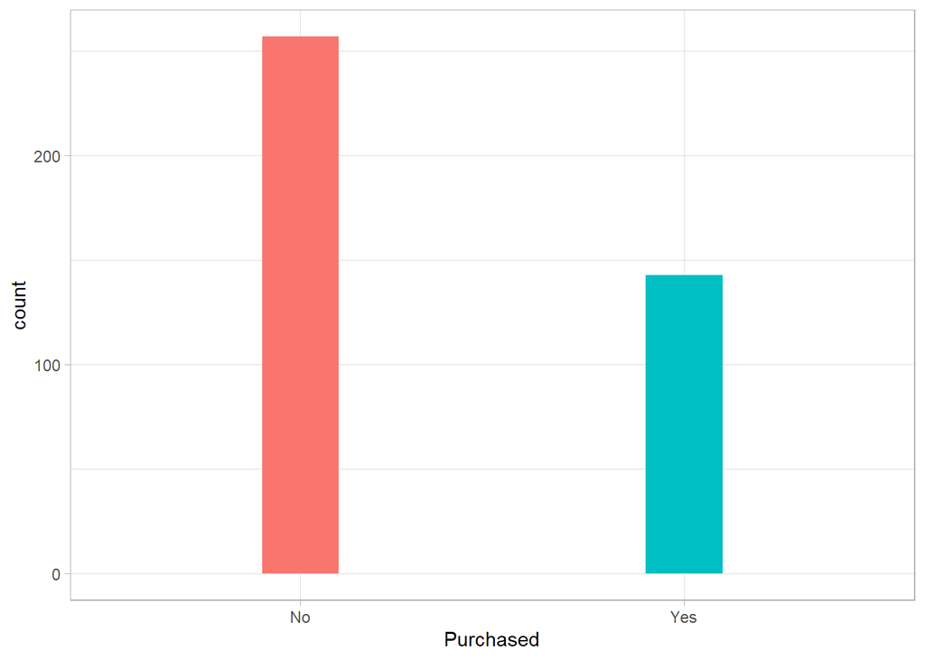

```r
ggplot(Data, aes(x = Purchased, fill = Purchased)) + geom_bar(width = 0.2, show.legend = FALSE) + theme_light()
```

The data set is split into training and testing data sets using the `rsample` package. We can however employ several packages to do the data partition.

- `caret`
- `base R function`
- `rsample`
- `h20`

80% of the data is used for training and 20% used for testing.

```r
# convert the character to factor

Data <- Data %>%
  mutate_if(is.character, as.factor)


set.seed(123) # for reproducibility

Index <- initial_split(Data, prop = 0.8)

Training <- training(Index)

Testing <- testing(Index)
```

Since we have the data set for training and testing we use the `caret` package to perform the machine learning. The features are `Gender, Age, Estimated Salary`. The target variable is `Purchased`.

We fit a model with the three features and assess the accuracy with the training set. We perform cross validation.

```r
set.seed(123)

# model 1

Model <- train(
  Purchased ~.,
  data = Training,
  method = "glm",
  family = "binomial",
  trControl = trainControl(method = "cv", number = 10)
)

# model 2

Model2 <- train(
  Purchased ~ Gender + Age,
  data = Training,
  method = "glm",
  family = "binomial",
  trControl = trainControl(method = "cv", number = 10)
)
```

Out of sample statistic. Model 1 is the best model with the highest accuracy so we choose that model to proceed.

```r
# out of sample measures

summary(
  resamples(
    list(
      model1 = Model,
      model2 = Model2
    )
  )
)$statistics$Accuracy
```

```
##         Min.   1st Qu.   Median      Mean   3rd Qu.    Max. NA's
## model1 0.750 0.7890625 0.859375 0.8500764 0.8971163 0.96875    0
## model2 0.625 0.7560484 0.828125 0.8185178 0.8918087 0.93750    0
```

The confusion matrix for the training set is given by:

```r
Preds <- predict(Model, Training)

confusionMatrix(
  data = relevel(Preds, ref = "Yes"),
  reference = relevel(Training$Purchased, ref = "Yes")
)
```

```
## Confusion Matrix and Statistics
##
##           Reference
## Prediction Yes  No
##        Yes  91  17
##        No   30 182
##
##                Accuracy : 0.8531
##                  95% CI : (0.8095, 0.89)
##     No Information Rate : 0.6219
##     P-Value [Acc > NIR] : < 2e-16
##
##                   Kappa : 0.681
##
##  Mcnemar's Test P-Value : 0.08005
##
##             Sensitivity : 0.7521
##             Specificity : 0.9146
##          Pos Pred Value : 0.8426
##          Neg Pred Value : 0.8585
##              Prevalence : 0.3781
##          Detection Rate : 0.2844
##    Detection Prevalence : 0.3375
##       Balanced Accuracy : 0.8333
##
##        'Positive' Class : Yes
##
```

The ROC curve for the training set is given below.

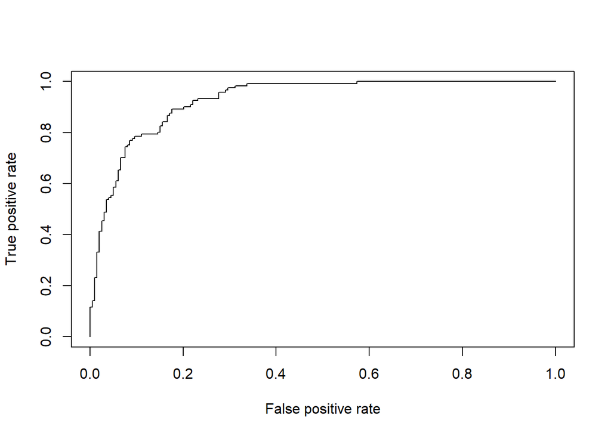

```r
library(ROCR)

PredTra <- predict(Model, Training, type = "prob")$"Yes"

Perf <- prediction(PredTra, Training$Purchased) %>%
  performance(measure = "tpr", x.measure = "fpr")
plot(Perf)
```

We implement our model to the test data.

```r
# checking on test data

TestP <- predict(Model, Testing)

confusionMatrix(
  data = relevel(TestP, ref = "Yes"),
  reference = relevel(Testing$Purchased, ref = "Yes")
)
```

```
## Confusion Matrix and Statistics
##
##           Reference
## Prediction Yes No
##        Yes  14  5
##        No    8 53
##
##                Accuracy : 0.8375
##                  95% CI : (0.7382, 0.9105)
##     No Information Rate : 0.725
##     P-Value [Acc > NIR] : 0.0134
##
##                   Kappa : 0.5745
##
##  Mcnemar's Test P-Value : 0.5791
##
##             Sensitivity : 0.6364
##             Specificity : 0.9138
##          Pos Pred Value : 0.7368
##          Neg Pred Value : 0.8689
##              Prevalence : 0.2750
##          Detection Rate : 0.1750
##    Detection Prevalence : 0.2375
##       Balanced Accuracy : 0.7751
##
##        'Positive' Class : Yes
##
```

The ROC curve for the testing data.

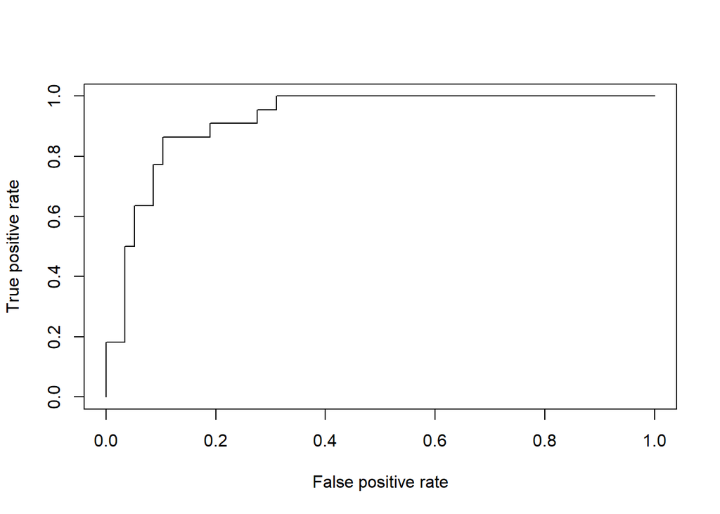

```r
TestR <- predict(Model, Testing,type = "prob")$"Yes"

PerT <- prediction(TestR,Testing$Purchased) %>%
  performance(measure = "tpr", x.measure = "fpr")
plot(PerT)
```